# Exam 1

Sean Schilk

10-12-2025

## Question 1

```r
setwd("~/STA419/REDO/5.UnsupLearning.CateVars")

data <- read.csv("Exam1data.csv")
  str(data)
```

```
## 'data.frame':    210 obs. of  7 variables:
##  $ Area            : num  15.3 14.9 14.3 13.8 16.1 ...
##  $ Perimeter       : num  14.8 14.6 14.1 13.9 15 ...
##  $ Compactness     : num  0.871 0.881 0.905 0.895 0.903 ...
##  $ LengthKern      : num  5.76 5.55 5.29 5.32 5.66 ...
##  $ WidthKern       : num  3.31 3.33 3.34 3.38 3.56 ...
##  $ AsymCoef        : num  2.22 1.02 2.7 2.26 1.35 ...
##  $ LengthKernGroove: num  5.22 4.96 4.83 4.8 5.17 ...
```

There are 210 observations and seven variables.

## Question 2

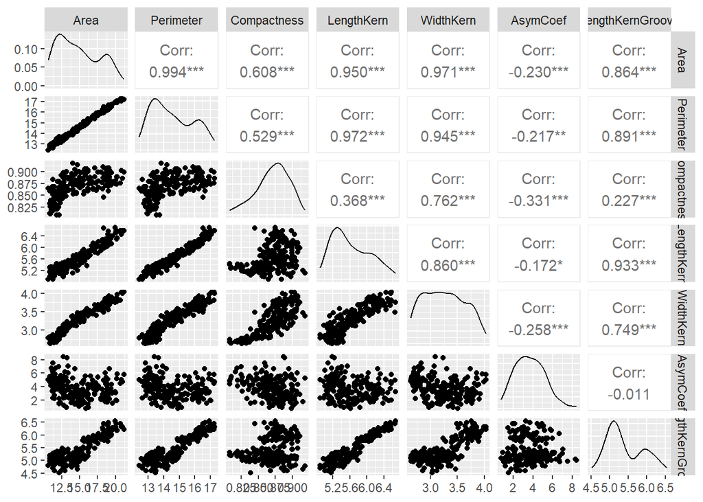

```r
library(GGally)

  ggpairs(data)
```

## Question 3

The first PC explains about 83% of the variation and the first two PCs explain a little over 99% of the variation.

```r
pca <- prcomp(data)
  summary(pca)
```

```
## Importance of components:
##                           PC1    PC2     PC3     PC4     PC5     PC6      PC7
## Standard deviation     3.2853 1.4593 0.27135 0.11352 0.05242 0.03963 0.005446
## Proportion of Variance 0.8294 0.1636 0.00566 0.00099 0.00021 0.00012 0.000000
## Cumulative Proportion  0.8294 0.9930 0.99868 0.99967 0.99988 1.00000 1.000000
```

## Question 4

```r
pca$rotation[ , 1:2]
```

```
##                           PC1          PC2
## Area             -0.884228505  0.100805775
## Perimeter        -0.395405417  0.056489625
## Compactness      -0.004311324 -0.002894744
## LengthKern       -0.128544478  0.030621731
## WidthKern        -0.111059139  0.002372293
## AsymCoef          0.127615624  0.989410476
## LengthKernGroove -0.128966499  0.082233392
```

```r
round(apply(data, 2, sd), 2)
```

```
##             Area        Perimeter      Compactness       LengthKern
##             2.91             1.31             0.02             0.44
##        WidthKern         AsymCoef LengthKernGroove
##             0.38             1.50             0.49
```

## Question 5

After scaling the variables first, the first two PCs explain about 89% of the original variation.

```r
pca.sc <- prcomp(data, scale = TRUE)
  summary(pca.sc)
```

```
## Importance of components:
##                           PC1    PC2     PC3     PC4     PC5     PC6     PC7
## Standard deviation     2.2430 1.0943 0.82341 0.26147 0.13680 0.07302 0.02850
## Proportion of Variance 0.7187 0.1711 0.09686 0.00977 0.00267 0.00076 0.00012
## Cumulative Proportion  0.7187 0.8898 0.98668 0.99645 0.99912 0.99988 1.00000
```

## Question 6

From the biplot, we can see that observation 102 is above observation 71. Notice that observation 102 has an above average Compactness value, while 71 is below average. This makes sense because Compactness is point “up.” AsymCoef is pointing the furthest “down.” Notice that observation 71 has a much higher (and above average) value for this variable than observation 102 (which is below average for this variable).

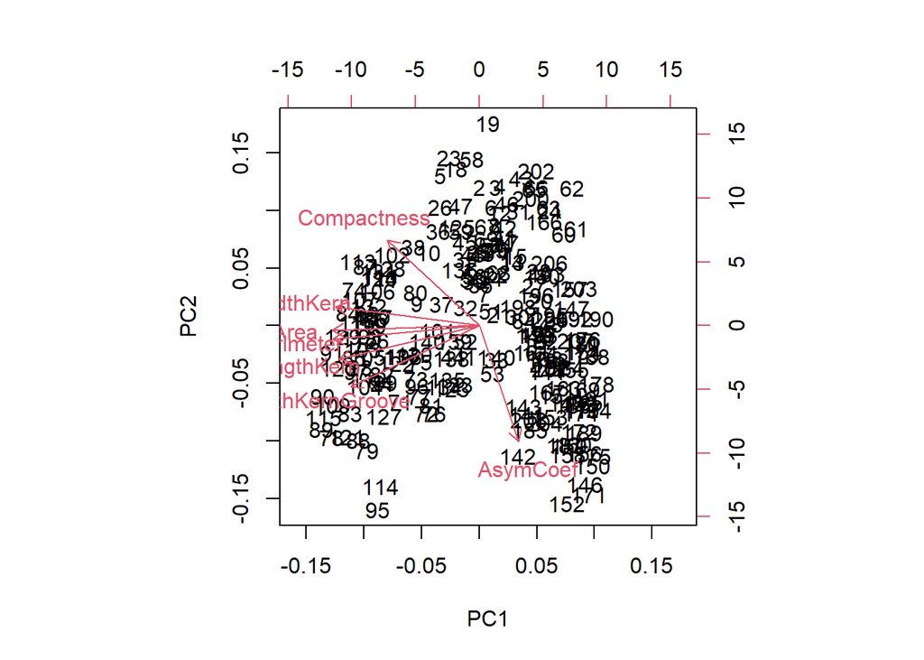

```r
  biplot(pca.sc)
```

```r
  data[c(71, 102), ]
```

|  | Area | Perimeter | Compactness | LengthKern | WidthKern | AsymCoef | LengthKernGroove |
| --- | --- | --- | --- | --- | --- | --- | --- |
| 71 | 17.63 | 15.98 | 0.8673 | 6.191 | 3.561 | 4.076 | 6.060 |
| 102 | 17.99 | 15.86 | 0.8992 | 5.890 | 3.694 | 2.068 | 5.837 |

```r
  round(apply(data, 2, mean), 2)
```

```
##             Area        Perimeter      Compactness       LengthKern
##            14.85            14.56             0.87             5.63
##        WidthKern         AsymCoef LengthKernGroove
##             3.26             3.70             5.41
```

## Question 7

Clustering on the first two PCs gives us one cluster with 133 observations and the other cluster with 77 observations.

```r
set.seed(1)
km.2.out <- kmeans(pca.sc$x[ , 1:2], 2, nstart = 20)
  table(km.2.out$cluster)
```

```
##
##   1   2
##  77 133
```

## Question 8

We get the same means for each variable after grouping by their cluster assignments.

```r
library(tidyverse)

clusters.2 <- as.character(km.2.out$cluster)

new.data <- data.frame(pca.sc$x[ ,1:2], clusters.2)

km.2.out$centers
```

```
##         PC1        PC2
## 1 -2.560586 -0.2749423
## 2  1.482445  0.1591771
```

```r
new.data %>%
  group_by(clusters.2) %>%
  summarize(mean(PC1), mean(PC2))
```

| clusters.2 | mean(PC1) | mean(PC2) |
| --- | --- | --- |
| 1 | -2.560586 | -0.2749423 |
| 2 | 1.482445 | 0.1591771 |

## Question 9

We can see from the plot that the clustering algorithm basically split the observations between having positive and negative values of PC1.

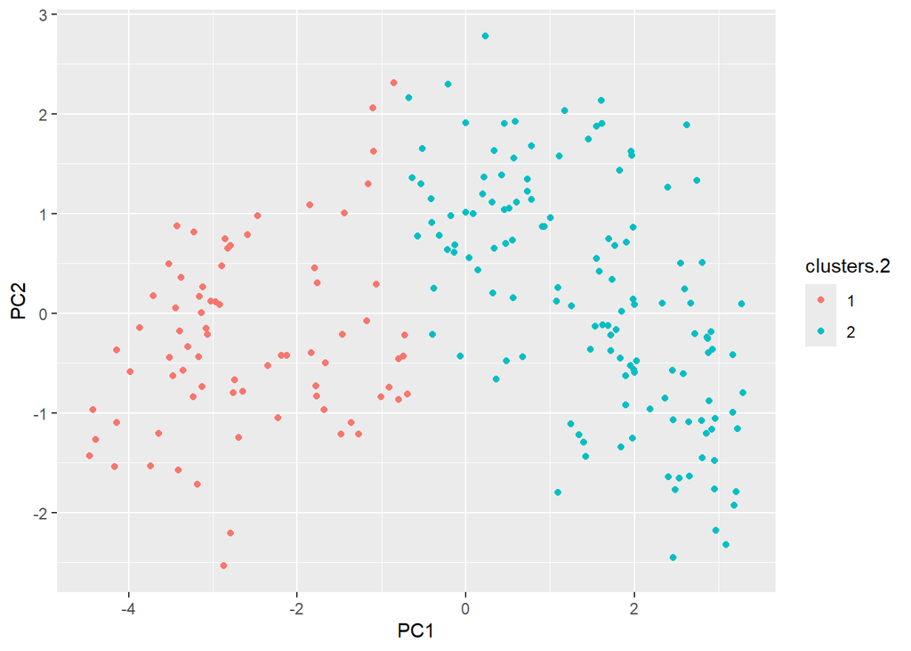

```r
ggplot(new.data, aes(x = PC1, y = PC2, col = clusters.2)) +
  geom_point( )
```

## Questions 10 - 11

There is a pretty clear elbow at $k = 3$. So, this seems like a reasonable number of clusters. And we can see that the observations are close to uniformly distributed across the three clusters (67, 71, and 72).

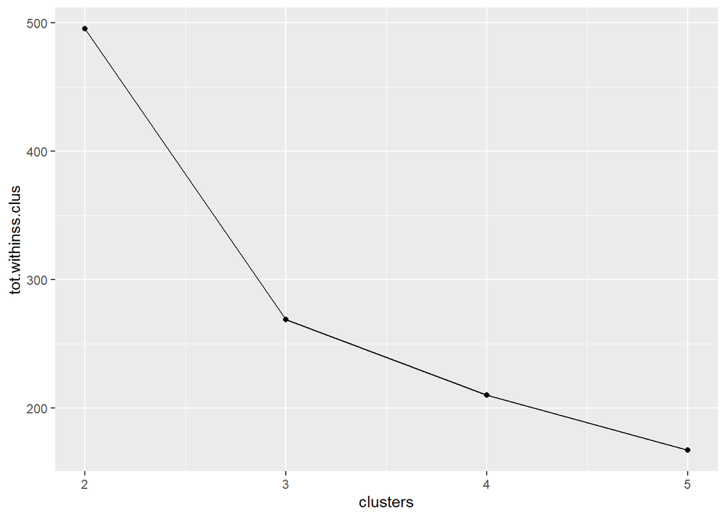

```r
km.3.out <- kmeans(pca.sc$x[ , 1:2], 3, nstart = 20)
km.4.out <- kmeans(pca.sc$x[ , 1:2], 4, nstart = 20)
km.5.out <- kmeans(pca.sc$x[ , 1:2], 5, nstart = 20)

clusters <- 2:5
tot.withinss.clus <- c(km.2.out$tot.withinss,
              km.3.out$tot.withinss,
              km.4.out$tot.withinss,
              km.5.out$tot.withinss)

frame <- data.frame(clusters, tot.withinss.clus)

ggplot(frame, aes(x = clusters, y = tot.withinss.clus)) +
  geom_point() +
  geom_line()
```

```r
table(km.3.out$cluster)
```

```
##
##  1  2  3
## 72 71 67
```

## Question 12

We get 9 clusters if we use a cut height of 0.50 and single linkage.

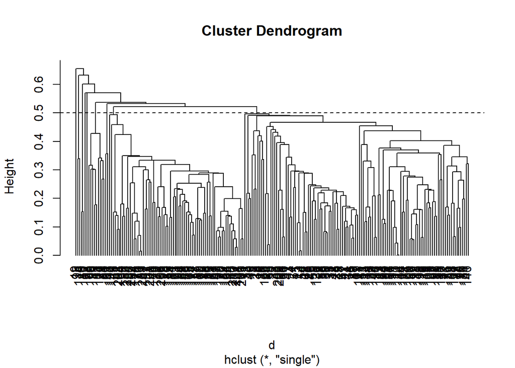

```r
d <- dist(pca.sc$x[ , 1:2])

hc.sing <- hclust(d, method = "single")
  plot(hc.sing, hang = -1)
  abline(h = 0.5, lty = 2)
```

```r
  clus.sing <- cutree(hc.sing, h = 0.5)
    table(clus.sing)
```

```
## clus.sing
##   1   2   3   4   5   6   7   8   9
## 120   2   1  72   2   1   9   2   1
```

## Question 13

```r
d.mat <- as.matrix(d)

  d.14 <- d.mat[which(clus.sing == "1"),
                which(clus.sing == "4")]

  min(d.14)
```

```
## [1] 0.5223089
```

## Question 14

Let’s compare the observations in cluster 1. The first observation in cluster 1 (observation 1) is within our cut height of at least nine other observations in this cluster. The second observation (observation 2) is within our cut height of three other observations in cluster 1. The third observation is within the cut height of five other observations in cluster 1.

```r
  d.11 <- d.mat[which(clus.sing == "1"),
                which(clus.sing == "1")]
  sort(d.11[1, ])[1:10]
```

```
##         1        35        56        50        48        39       136        45
## 0.0000000 0.1551397 0.1731444 0.2136057 0.2429719 0.2467720 0.2514112 0.3801845
##        25        55
## 0.3917915 0.4186896
```

```r
  sort(d.11[2, ])[1:10]
```

```
##         2         6        58         3        47        67         4        12
## 0.0000000 0.4319979 0.4412739 0.4550092 0.5764748 0.5814103 0.5874166 0.6692978
##         8        18
## 0.6705002 0.7275186
```

```r
  sort(d.11[3, ])[1:10]
```

```
##         3         4         6        12        46         2         8        67
## 0.0000000 0.1342998 0.2961167 0.3660194 0.3915763 0.4550092 0.5169535 0.5883947
##        42        31
## 0.6204396 0.7277973
```

## Question 15

I chose a cut height of 5 because we can see there are a lot of long, vertical jumps before we merge groups together at that height. This makes three clusters: 74 observations in one cluster, 73 in another, and 63 in the third.

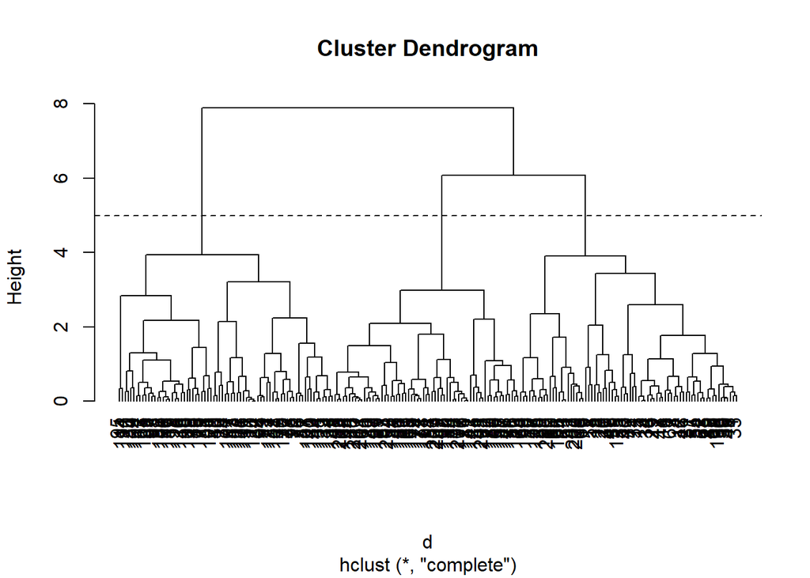

```r
hc.comp <- hclust(d, method = "complete")
  plot(hc.comp, hang = -1)
  abline(h = 5, lty = 2)
```

```r
  clus.comp <- cutree(hc.comp, h = 5)
    table(clus.comp)
```

```
## clus.comp
##  1  2  3
## 74 73 63
```

## Question 16 - 17

The maximum distance between any two observations in cluster one is 3.912. This is less than our cut height of 5. This must be the case using complete linkage because all observations within a cluster must be within our cut height. The maximum distance between any two observations in cluster three is 2.981, which is also less than our cut height.

```r
    d.11 <- d.mat[which(clus.comp == "1"),
                  which(clus.comp == "1")]

      max(d.11)
```

```
## [1] 3.912111
```

```r
    d.33 <- d.mat[which(clus.comp == "3"),
                  which(clus.comp == "3")]

      max(d.33)
```

```
## [1] 2.980608
```

```r
    d.13 <- d.mat[which(clus.comp == "1"),
                  which(clus.comp == "3")]

      max(d.13)
```

```
## [1] 6.084787
```